# Project 1: Wrangling, Exploration, Visualization

#### Wrangling

```r
fulldata <- fulldata %>% rename(price = "avg_Price_recent") %>%
    rename(sqft = "avg_SqFt") %>% rename(tax = "avg_tax") %>%
    rename(ReviewCount = "avg_review_count") %>% rename(CategoryCount = "Category_Count") %>%
    rename(InspectionScore = "avg_Inspection_Score")

# dplyr functions
fulldata %>% group_by(zipcode) %>% summarise(mean = mean(sqft))
```

```
## # A tibble: 44 x 2
##    zipcode     mean
##      <dbl>    <dbl>
##  1   78617    6452.
##  2   78652    7429.
##  3   78653   30612.
##  4   78660    8032.
##  5   78701    3410.
##  6   78702    6033.
##  7   78703 5020442.
##  8   78704    7835.
##  9   78705  507848.
## 10   78717   32041.
## # … with 34 more rows
```

```r
fulldata %>% select(zipcode, sqft, CategoryCount) %>% arrange(sqft)
```

```
## # A tibble: 44 x 3
## # Groups:   zipcode [44]
##    zipcode  sqft CategoryCount
##      <dbl> <dbl>         <int>
##  1   78701 3410.           148
##  2   78702 6033.           106
##  3   78617 6452.             4
##  4   78751 6577.            41
##  5   78725 6726.             1
##  6   78728 6913.             3
##  7   78738 6969              2
##  8   78652 7429.             1
##  9   78744 7435.             9
## 10   78741 7575.            24
## # … with 34 more rows
```

```r
fulldata %>% summarise(H_R_Ratio = (sqft/CategoryCount)) %>%
    arrange(H_R_Ratio)
```

```
## # A tibble: 44 x 2
##    zipcode H_R_Ratio
##      <dbl>     <dbl>
##  1   78701      23.0
##  2   78702      56.9
##  3   78704      64.2
##  4   78751     160.
##  5   78758     187.
##  6   78756     237.
##  7   78745     302.
##  8   78753     314.
##  9   78741     316.
## 10   78722     376.
## # … with 34 more rows
```

```r
fulldata %>% mutate(full_price = price * tax)
```

```
## # A tibble: 44 x 8
## # Groups:   zipcode [44]
##    zipcode  price   sqft   tax ReviewCount CategoryCount InspectionScore
##      <dbl>  <dbl>  <dbl> <dbl>       <dbl>         <int>           <dbl>
##  1   78660 2.86e5  8032.  1.98        65.7             3            93.2
##  2   78617 1.97e5  6452.  1.98        78.5             4            91.1
##  3   78717 4.33e5 32041.  2.21       295.              5            92.5
##  4   78724 2.79e5  7681.  1.98        31.2             4            90.9
##  5   78747 2.95e5 12034.  1.98         3               1            90
##  6   78725 2.25e5  6726.  1.98        12               1            93.9
##  7   78726 5.10e5 12186.  1.98       185.              3            94.3
##  8   78744 2.69e5  7435.  1.98        63.9             9            91.1
##  9   78732 7.07e5 32733.  1.98       268.              6            94.4
## 10   78750 5.81e5 14626.  2.00       210.             12            92.2
## # … with 34 more rows, and 1 more variable: full_price <dbl>
```

```r
# summary statistics - overall - mean, sd, var, n, quantile,
# min, max, n_distinct, cor
fulldata1 <- fulldata %>% ungroup() %>% select(1:7) %>% summarise_each(funs(mean = mean,
    sd = sd, min = min, max = max, median = median))

fulldata %>% ungroup() %>% summarise(quantile(price))
```

```
## # A tibble: 5 x 1
##   `quantile(price)`
##               <dbl>
## 1           196883.
## 2           331176.
## 3           421020.
## 4           666238.
## 5          1418161.
```

```r
fulldata %>% ungroup() %>% summarise(n_distinct(price))
```

```
## # A tibble: 1 x 1
##   `n_distinct(price)`
##                 <int>
## 1                  44
```

```r
fulldata %>% ungroup() %>% summarise(r = cor(price, InspectionScore,
    use = "pair"))
```

```
## # A tibble: 1 x 1
##       r
##   <dbl>
## 1 0.180
```

```r
fulldata %>% ungroup() %>% summarise(avg = (sum(price)/n_distinct(price)))
```

```
## # A tibble: 1 x 1
##       avg
##     <dbl>
## 1 537221.
```

```r
fulldata %>% ungroup() %>% summarise(quantile(sqft))
```

```
## # A tibble: 5 x 1
##   `quantile(sqft)`
##              <dbl>
## 1            3410.
## 2            7796.
## 3            9890.
## 4           23881.
## 5         5020442.
```

```r
fulldata %>% ungroup() %>% summarise(n_distinct(sqft))
```

```
## # A tibble: 1 x 1
##   `n_distinct(sqft)`
##                <int>
## 1                 44
```

```r
fulldata %>% ungroup() %>% summarise(r = cor(sqft, InspectionScore,
    use = "pair"))
```

```
## # A tibble: 1 x 1
##        r
##    <dbl>
## 1 -0.131
```

```r
fulldata %>% ungroup() %>% summarise(avg = (sum(sqft)/n_distinct(sqft)))
```

```
## # A tibble: 1 x 1
##       avg
##     <dbl>
## 1 143538.
```

```r
fulldata %>% ungroup() %>% summarise(quantile(tax))
```

```
## # A tibble: 5 x 1
##   `quantile(tax)`
##             <dbl>
## 1            1.98
## 2            1.98
## 3            1.98
## 4            1.98
## 5            2.21
```

```r
fulldata %>% ungroup() %>% summarise(n_distinct(tax))
```

```
## # A tibble: 1 x 1
##   `n_distinct(tax)`
##               <int>
## 1                 9
```

```r
fulldata %>% ungroup() %>% summarise(r = cor(tax, InspectionScore,
    use = "pair"))
```

```
## # A tibble: 1 x 1
##         r
##     <dbl>
## 1 -0.0435
```

```r
fulldata %>% ungroup() %>% summarise(avg = (sum(tax)/n_distinct(tax)))
```

```
## # A tibble: 1 x 1
##     avg
##   <dbl>
## 1  9.74
```

```r
fulldata %>% ungroup() %>% summarise(quantile(ReviewCount))
```

```
## # A tibble: 5 x 1
##   `quantile(ReviewCount)`
##                     <dbl>
## 1                     3
## 2                    96.8
## 3                   208.
## 4                   290.
## 5                   444.
```

```r
fulldata %>% ungroup() %>% summarise(n_distinct(ReviewCount))
```

```
## # A tibble: 1 x 1
##   `n_distinct(ReviewCount)`
##                       <int>
## 1                        44
```

```r
fulldata %>% ungroup() %>% summarize(r = cor(ReviewCount, price,
    use = "pair"))
```

```
## # A tibble: 1 x 1
##       r
##   <dbl>
## 1 0.343
```

```r
fulldata %>% ungroup() %>% summarise(avg = (sum(ReviewCount)/n_distinct(ReviewCount)))
```

```
## # A tibble: 1 x 1
##     avg
##   <dbl>
## 1  203.
```

```r
fulldata %>% ungroup() %>% summarise(quantile(CategoryCount))
```

```
## # A tibble: 5 x 1
##   `quantile(CategoryCount)`
##                       <dbl>
## 1                       1
## 2                       3
## 3                       6.5
## 4                      29.2
## 5                     148
```

```r
fulldata %>% ungroup() %>% summarise(n_distinct(CategoryCount))
```

```
## # A tibble: 1 x 1
##   `n_distinct(CategoryCount)`
##                         <int>
## 1                          25
```

```r
fulldata %>% ungroup() %>% summarize(r = cor(CategoryCount, price,
    use = "pair"))
```

```
## # A tibble: 1 x 1
##       r
##   <dbl>
## 1 0.334
```

```r
fulldata %>% ungroup() %>% summarise(avg = (sum(CategoryCount)/n_distinct(CategoryCount)))
```

```
## # A tibble: 1 x 1
##     avg
##   <dbl>
## 1  38.4
```

```r
fulldata %>% ungroup() %>% summarise(quantile(InspectionScore))
```

```
## # A tibble: 5 x 1
##   `quantile(InspectionScore)`
##                         <dbl>
## 1                        88.1
## 2                        90.7
## 3                        92.2
## 4                        93.4
## 5                        95.9
```

```r
fulldata %>% ungroup() %>% summarise(n_distinct(InspectionScore))
```

```
## # A tibble: 1 x 1
##   `n_distinct(InspectionScore)`
##                           <int>
## 1                            44
```

```r
fulldata %>% ungroup() %>% summarize(r = cor(InspectionScore,
    price, use = "pair"))
```

```
## # A tibble: 1 x 1
##       r
##   <dbl>
## 1 0.180
```

```r
fulldata %>% ungroup() %>% summarise(avg = (sum(InspectionScore)/n_distinct(InspectionScore)))
```

```
## # A tibble: 1 x 1
##     avg
##   <dbl>
## 1  92.0
```

```r
fulldata %>% group_by(zipcode) %>% n_distinct  #no NAs
```

```
## [1] 44
```

```r
# summary statistics - grouped by - mean, sd, var, n,
# quantile, min, max, n_distinct, cor, user defined function
fulldata %>% group_by(tax) %>% select(1:7) %>% summarise_each(funs(mean = mean,
    sd = sd, var = var, min = min, max = max, median = median,
    n_distinct = n_distinct))
```

```
## # A tibble: 9 x 43
##     tax zipcode_mean price_mean sqft_mean ReviewCount_mean CategoryCount_m…
##   <dbl>        <dbl>      <dbl>     <dbl>            <dbl>            <dbl>
## 1  1.98       78726.    559388.   170472.             203.             25.1
## 2  1.98       78736     409211.    20334.             123               2
## 3  1.98       78728     301055.     6913.             291.              3
## 4  1.98       78759     517559.    12362.             251.             29
## 5  1.99       78652     375340.     7429.              25               1
## 6  2.00       78750     581451.    14626.             210.             12
## 7  2.01       78737     544287.    74396.             272.              3
## 8  2.20       78729     338003.    10578.             182.              2
## 9  2.21       78717     432830.    32041.             295.              5
## # … with 37 more variables: InspectionScore_mean <dbl>, zipcode_sd <dbl>,
## #   price_sd <dbl>, sqft_sd <dbl>, ReviewCount_sd <dbl>,
## #   CategoryCount_sd <dbl>, InspectionScore_sd <dbl>, zipcode_var <dbl>,
## #   price_var <dbl>, sqft_var <dbl>, ReviewCount_var <dbl>,
## #   CategoryCount_var <dbl>, InspectionScore_var <dbl>, zipcode_min <dbl>,
## #   price_min <dbl>, sqft_min <dbl>, ReviewCount_min <dbl>,
## #   CategoryCount_min <int>, InspectionScore_min <dbl>, zipcode_max <dbl>,
## #   price_max <dbl>, sqft_max <dbl>, ReviewCount_max <dbl>,
## #   CategoryCount_max <int>, InspectionScore_max <dbl>, zipcode_median <dbl>,
## #   price_median <dbl>, sqft_median <dbl>, ReviewCount_median <dbl>,
## #   CategoryCount_median <dbl>, InspectionScore_median <dbl>,
## #   zipcode_n_distinct <int>, price_n_distinct <int>, sqft_n_distinct <int>,
## #   ReviewCount_n_distinct <int>, CategoryCount_n_distinct <int>,
## #   InspectionScore_n_distinct <int>
```

```r
fulldata %>% group_by(tax) %>% summarise(quantile(price))
```

```
## # A tibble: 45 x 2
## # Groups:   tax [9]
##      tax `quantile(price)`
##    <dbl>             <dbl>
##  1  1.98           196883.
##  2  1.98           321860.
##  3  1.98           415232.
##  4  1.98           699610.
##  5  1.98          1418161.
##  6  1.98           409211.
##  7  1.98           409211.
##  8  1.98           409211.
##  9  1.98           409211.
## 10  1.98           409211.
## # … with 35 more rows
```

```r
fulldata %>% group_by(tax) %>% summarise(n_distinct(price))
```

```
## # A tibble: 9 x 2
##     tax `n_distinct(price)`
##   <dbl>               <int>
## 1  1.98                  36
## 2  1.98                   1
## 3  1.98                   1
## 4  1.98                   1
## 5  1.99                   1
## 6  2.00                   1
## 7  2.01                   1
## 8  2.20                   1
## 9  2.21                   1
```

```r
fulldata %>% group_by(tax) %>% summarize(r = cor(price, InspectionScore,
    use = "pair"))
```

```
## # A tibble: 9 x 2
##     tax      r
##   <dbl>  <dbl>
## 1  1.98  0.200
## 2  1.98 NA
## 3  1.98 NA
## 4  1.98 NA
## 5  1.99 NA
## 6  2.00 NA
## 7  2.01 NA
## 8  2.20 NA
## 9  2.21 NA
```

```r
fulldata %>% group_by(tax) %>% summarise(avg = (sum(price)/n_distinct(price)))
```

```
## # A tibble: 9 x 2
##     tax     avg
##   <dbl>   <dbl>
## 1  1.98 559388.
## 2  1.98 409211.
## 3  1.98 301055.
## 4  1.98 517559.
## 5  1.99 375340.
## 6  2.00 581451.
## 7  2.01 544287.
## 8  2.20 338003.
## 9  2.21 432830.
```

```r
fulldata %>% group_by(tax) %>% summarise(quantile(sqft))
```

```
## # A tibble: 45 x 2
## # Groups:   tax [9]
##      tax `quantile(sqft)`
##    <dbl>            <dbl>
##  1  1.98            3410.
##  2  1.98            7796.
##  3  1.98            9073.
##  4  1.98           23881.
##  5  1.98         5020442.
##  6  1.98           20334.
##  7  1.98           20334.
##  8  1.98           20334.
##  9  1.98           20334.
## 10  1.98           20334.
## # … with 35 more rows
```

```r
fulldata %>% group_by(tax) %>% summarise(n_distinct(sqft))
```

```
## # A tibble: 9 x 2
##     tax `n_distinct(sqft)`
##   <dbl>              <int>
## 1  1.98                 36
## 2  1.98                  1
## 3  1.98                  1
## 4  1.98                  1
## 5  1.99                  1
## 6  2.00                  1
## 7  2.01                  1
## 8  2.20                  1
## 9  2.21                  1
```

```r
fulldata %>% group_by(tax) %>% summarize(r = cor(sqft, InspectionScore,
    use = "pair"))
```

```
## # A tibble: 9 x 2
##     tax      r
##   <dbl>  <dbl>
## 1  1.98 -0.137
## 2  1.98 NA
## 3  1.98 NA
## 4  1.98 NA
## 5  1.99 NA
## 6  2.00 NA
## 7  2.01 NA
## 8  2.20 NA
## 9  2.21 NA
```

```r
fulldata %>% group_by(tax) %>% summarise(avg = (sum(sqft)/n_distinct(sqft)))
```

```
## # A tibble: 9 x 2
##     tax     avg
##   <dbl>   <dbl>
## 1  1.98 170472.
## 2  1.98  20334.
## 3  1.98   6913.
## 4  1.98  12362.
## 5  1.99   7429.
## 6  2.00  14626.
## 7  2.01  74396.
## 8  2.20  10578.
## 9  2.21  32041.
```

```r
fulldata %>% group_by(tax) %>% summarise(quantile(zipcode))
```

```
## # A tibble: 45 x 2
## # Groups:   tax [9]
##      tax `quantile(zipcode)`
##    <dbl>               <dbl>
##  1  1.98              78617
##  2  1.98              78720.
##  3  1.98              78732.
##  4  1.98              78747.
##  5  1.98              78758
##  6  1.98              78736
##  7  1.98              78736
##  8  1.98              78736
##  9  1.98              78736
## 10  1.98              78736
## # … with 35 more rows
```

```r
fulldata %>% group_by(tax) %>% summarise(n_distinct(zipcode))
```

```
## # A tibble: 9 x 2
##     tax `n_distinct(zipcode)`
##   <dbl>                 <int>
## 1  1.98                    36
## 2  1.98                     1
## 3  1.98                     1
## 4  1.98                     1
## 5  1.99                     1
## 6  2.00                     1
## 7  2.01                     1
## 8  2.20                     1
## 9  2.21                     1
```

```r
fulldata %>% group_by(tax) %>% summarize(r = cor(zipcode, InspectionScore,
    use = "pair"))
```

```
## # A tibble: 9 x 2
##     tax       r
##   <dbl>   <dbl>
## 1  1.98 -0.0424
## 2  1.98 NA
## 3  1.98 NA
## 4  1.98 NA
## 5  1.99 NA
## 6  2.00 NA
## 7  2.01 NA
## 8  2.20 NA
## 9  2.21 NA
```

```r
fulldata %>% group_by(tax) %>% summarise(avg = (sum(zipcode)/n_distinct(zipcode)))
```

```
## # A tibble: 9 x 2
##     tax    avg
##   <dbl>  <dbl>
## 1  1.98 78726.
## 2  1.98 78736
## 3  1.98 78728
## 4  1.98 78759
## 5  1.99 78652
## 6  2.00 78750
## 7  2.01 78737
## 8  2.20 78729
## 9  2.21 78717
```

```r
fulldata %>% group_by(tax) %>% summarise(quantile(ReviewCount))
```

```
## # A tibble: 45 x 2
## # Groups:   tax [9]
##      tax `quantile(ReviewCount)`
##    <dbl>                   <dbl>
##  1  1.98                     3
##  2  1.98                    93.0
##  3  1.98                   204.
##  4  1.98                   296.
##  5  1.98                   444.
##  6  1.98                   123
##  7  1.98                   123
##  8  1.98                   123
##  9  1.98                   123
## 10  1.98                   123
## # … with 35 more rows
```

```r
fulldata %>% group_by(tax) %>% summarise(n_distinct(ReviewCount))
```

```
## # A tibble: 9 x 2
##     tax `n_distinct(ReviewCount)`
##   <dbl>                     <int>
## 1  1.98                        36
## 2  1.98                         1
## 3  1.98                         1
## 4  1.98                         1
## 5  1.99                         1
## 6  2.00                         1
## 7  2.01                         1
## 8  2.20                         1
## 9  2.21                         1
```

```r
fulldata %>% group_by(tax) %>% summarize(r = cor(ReviewCount,
    price, use = "pair"))
```

```
## # A tibble: 9 x 2
##     tax      r
##   <dbl>  <dbl>
## 1  1.98  0.362
## 2  1.98 NA
## 3  1.98 NA
## 4  1.98 NA
## 5  1.99 NA
## 6  2.00 NA
## 7  2.01 NA
## 8  2.20 NA
## 9  2.21 NA
```

```r
fulldata %>% group_by(tax) %>% summarise(avg = (sum(ReviewCount)/n_distinct(ReviewCount)))
```

```
## # A tibble: 9 x 2
##     tax   avg
##   <dbl> <dbl>
## 1  1.98  203.
## 2  1.98  123
## 3  1.98  291.
## 4  1.98  251.
## 5  1.99   25
## 6  2.00  210.
## 7  2.01  272.
## 8  2.20  182.
## 9  2.21  295.
```

```r
fulldata %>% group_by(tax) %>% summarise(quantile(CategoryCount))
```

```
## # A tibble: 45 x 2
## # Groups:   tax [9]
##      tax `quantile(CategoryCount)`
##    <dbl>                     <dbl>
##  1  1.98                       1
##  2  1.98                       3
##  3  1.98                       8
##  4  1.98                      32.8
##  5  1.98                     148
##  6  1.98                       2
##  7  1.98                       2
##  8  1.98                       2
##  9  1.98                       2
## 10  1.98                       2
## # … with 35 more rows
```

```r
fulldata %>% group_by(tax) %>% summarise(n_distinct(CategoryCount))
```

```
## # A tibble: 9 x 2
##     tax `n_distinct(CategoryCount)`
##   <dbl>                       <int>
## 1  1.98                          24
## 2  1.98                           1
## 3  1.98                           1
## 4  1.98                           1
## 5  1.99                           1
## 6  2.00                           1
## 7  2.01                           1
## 8  2.20                           1
## 9  2.21                           1
```

```r
fulldata %>% group_by(tax) %>% summarize(r = cor(CategoryCount,
    price, use = "pair"))
```

```
## # A tibble: 9 x 2
##     tax      r
##   <dbl>  <dbl>
## 1  1.98  0.307
## 2  1.98 NA
## 3  1.98 NA
## 4  1.98 NA
## 5  1.99 NA
## 6  2.00 NA
## 7  2.01 NA
## 8  2.20 NA
## 9  2.21 NA
```

```r
fulldata %>% group_by(tax) %>% summarise(avg = (sum(CategoryCount)/n_distinct(CategoryCount)))
```

```
## # A tibble: 9 x 2
##     tax   avg
##   <dbl> <dbl>
## 1  1.98  37.6
## 2  1.98   2
## 3  1.98   3
## 4  1.98  29
## 5  1.99   1
## 6  2.00  12
## 7  2.01   3
## 8  2.20   2
## 9  2.21   5
```

```r
fulldata %>% group_by(tax) %>% summarise(quantile(InspectionScore))
```

```
## # A tibble: 45 x 2
## # Groups:   tax [9]
##      tax `quantile(InspectionScore)`
##    <dbl>                       <dbl>
##  1  1.98                        88.1
##  2  1.98                        90.6
##  3  1.98                        92.0
##  4  1.98                        93.8
##  5  1.98                        95.3
##  6  1.98                        92.5
##  7  1.98                        92.5
##  8  1.98                        92.5
##  9  1.98                        92.5
## 10  1.98                        92.5
## # … with 35 more rows
```

```r
fulldata %>% group_by(tax) %>% summarise(n_distinct(InspectionScore))
```

```
## # A tibble: 9 x 2
##     tax `n_distinct(InspectionScore)`
##   <dbl>                         <int>
## 1  1.98                            36
## 2  1.98                             1
## 3  1.98                             1
## 4  1.98                             1
## 5  1.99                             1
## 6  2.00                             1
## 7  2.01                             1
## 8  2.20                             1
## 9  2.21                             1
```

```r
fulldata %>% group_by(tax) %>% summarize(r = cor(InspectionScore,
    price, use = "pair"))
```

```
## # A tibble: 9 x 2
##     tax      r
##   <dbl>  <dbl>
## 1  1.98  0.200
## 2  1.98 NA
## 3  1.98 NA
## 4  1.98 NA
## 5  1.99 NA
## 6  2.00 NA
## 7  2.01 NA
## 8  2.20 NA
## 9  2.21 NA
```

```r
fulldata %>% group_by(tax) %>% summarise(avg = (sum(InspectionScore)/n_distinct(InspectionScore)))
```

```
## # A tibble: 9 x 2
##     tax   avg
##   <dbl> <dbl>
## 1  1.98  92.0
## 2  1.98  92.5
## 3  1.98  90.1
## 4  1.98  92.3
## 5  1.99  95.9
## 6  2.00  92.2
## 7  2.01  92.5
## 8  2.20  90.6
## 9  2.21  92.5
```

```r
# table of summary statistics
table1_data <- fulldata1 %>% pivot_longer(cols = (1:35), names_to = "variable",
    values_to = "value") %>% separate(variable, into = c("category",
    "stat"), sep = "_") %>% pivot_wider(names_from = "stat",
    values_from = "value")
table1_data
```

```
## # A tibble: 7 x 6
##   category             mean          sd       min        max    median
##   <chr>               <dbl>       <dbl>     <dbl>      <dbl>     <dbl>
## 1 zipcode          78726.       30.7     78617      78759     78732.
## 2 price           537221.   304845.     196883.   1418161.   421020.
## 3 sqft            143538.   756276.       3410.   5020442.     9890.
## 4 tax                  1.99      0.0473      1.98       2.21      1.98
## 5 ReviewCount        203.      115.          3        444.      208.
## 6 CategoryCount       21.8      32.1         1        148         6.5
## 7 InspectionScore     92.0       1.86       88.1       95.9      92.2
```

```r
library(gt)

table1 <- table1_data %>% gt %>% tab_header(title = md("**Summary Statistics**"),
    subtitle = md("A table of my `table1_data` summary statistics")) %>%
    tab_spanner(label = "Variables", columns = c("category",
        "mean", "sd", "min", "max", "median"))

table1
```

**Summary Statistics**

A table of my `table1_data` summary statistics

| Variables category | Variables mean | Variables sd | Variables min | Variables max | Variables median |
| --- | --- | --- | --- | --- | --- |
| zipcode | 78725.93182 | 3.073170e+01 | 78617.0000 | 7.875900e+04 | 78731.5000 |
| price | 537220.52610 | 3.048454e+05 | 196883.3176 | 1.418161e+06 | 421020.1752 |
| sqft | 143537.99864 | 7.562758e+05 | 3410.3500 | 5.020442e+06 | 9890.0684 |
| tax | 1.99155 | 4.728695e-02 | 1.9800 | 2.210000e+00 | 1.9800 |
| ReviewCount | 203.48261 | 1.145935e+02 | 3.0000 | 4.441967e+02 | 208.5000 |
| CategoryCount | 21.81818 | 3.214522e+01 | 1.0000 | 1.480000e+02 | 6.5000 |
| InspectionScore | 92.04188 | 1.859139e+00 | 88.0775 | 9.585714e+01 | 92.1849 |

*For the second portion I did summary statistics for each of my variables including mean, sd, var, n, quantile, min, max, n_distinct, and cor. All of my variables were numeric except for zipcode which I classified as a categorical variable so I performed a count for zip code to find 44 unique counts. There were no NA’s. I also created a user-generate function to find mean. I do not have any variables that have text so I am unable to use any stringr functions.*

*For the third portion, I did another set of summary statistics including mean, sd, var, n, quantile, min, max, n_distinct, and cor, but by grouping one of the variables. The data is already grouped by zipcode and since I don’t have any other categorical variables, I converted the avg_tax variable into a categorical variable so that it would have 9 distinct categories to work with.*

*The last portion includes a table of my summary statistics including mean, median, min, max, and sd for each of my variables.*

#### Visualizing

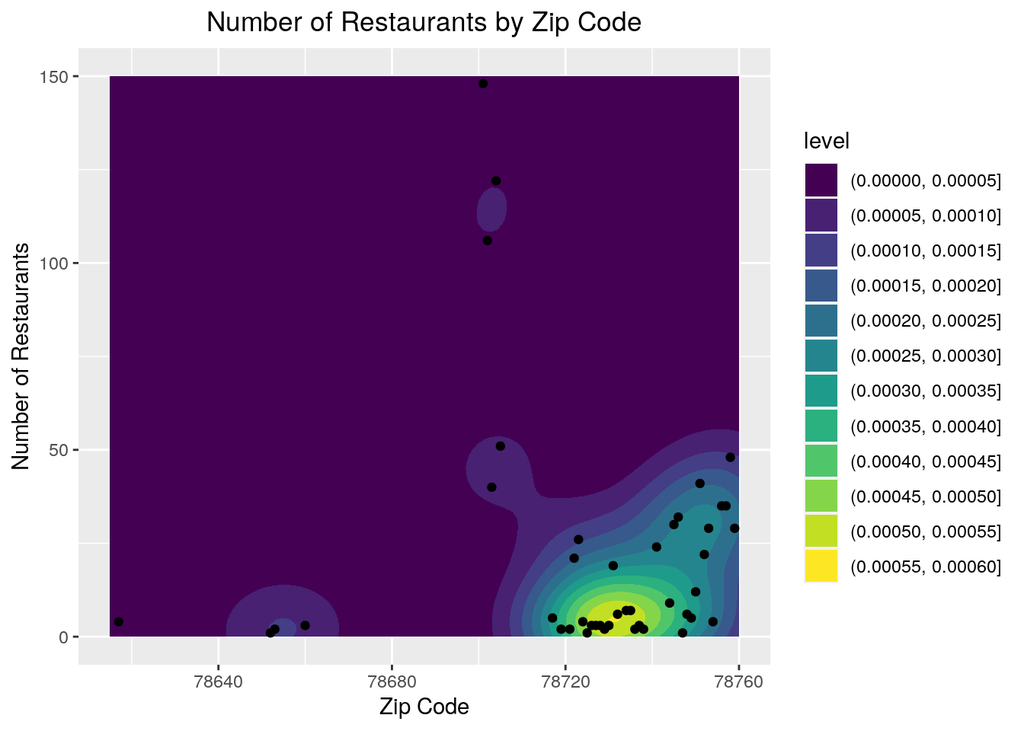

```r
library(ggplot2)
fulldata %>% ggplot(aes(zipcode, CategoryCount)) + geom_density2d_filled() +
    geom_count(stat = "summary") + scale_x_continuous(name = "Zip Code",
    lim = c(78615, 78760)) + scale_y_continuous(name = "Number of Restaurants",
    lim = c(0, 150)) + ggtitle("Number of Restaurants by Zip Code") +
    theme(plot.title = element_text(hjust = 0.5))
```

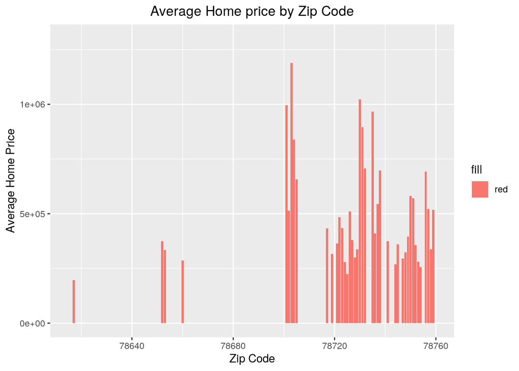

```r
ggplot(fulldata, aes(x = zipcode, y = price, fill = "red")) +
    geom_bar(stat = "summary") + geom_errorbar(stat = "summary") +
    scale_x_continuous(name = "Zip Code", lim = c(78615, 78760)) +
    scale_y_continuous(name = "Average Home Price", lim = c(0,
        1300000)) + ggtitle("Average Home price by Zip Code") +
    theme(plot.title = element_text(hjust = 0.5))
```

*If you’ve ever wondered what some of the most or least expensive places to live in Austin are by zip code, this graph is for you! This graph plots average home price by location (zip code). It does not show geographically where these locations are, but it demonstrates which zipcodes are home to some of Austin’s most and least expensive homes*

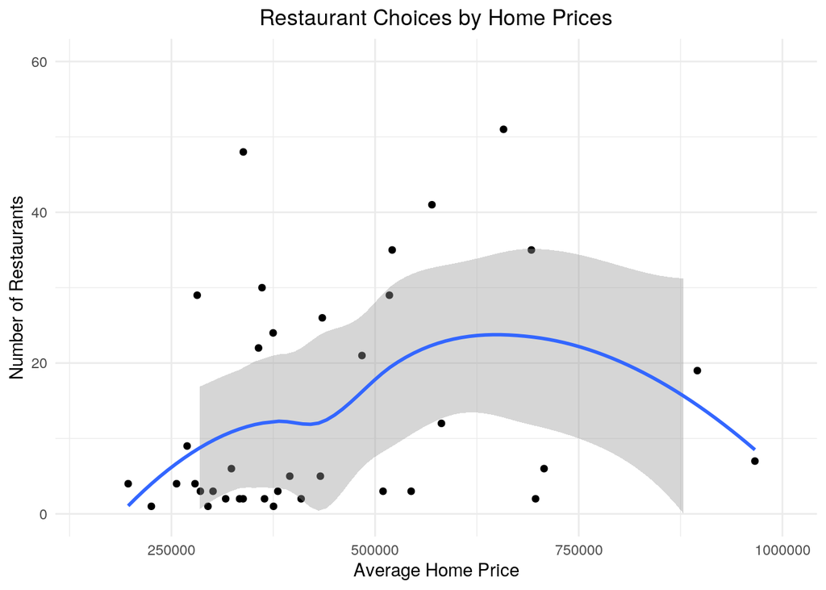

```r
fulldata %>% ggplot(aes(price, CategoryCount)) + geom_point() +
    scale_x_continuous(lim = c(150000, 1e+06)) + scale_y_continuous(lim = c(0,
    60)) + geom_smooth() + xlab("Average Home Price") + ylab("Number of Restaurants") +
    ggtitle("Restaurant Choices by Home Prices") + theme_minimal() +
    theme(plot.title = element_text(hjust = 0.5))
```

*The plot “Restaurant Choices by Home Price” is a graph that shows the relationship between number of restaurant options and home prices. This graph was to created to identify if a pattern exists among the two variables. It looks like there are slightly more restaurant options near more expensive houses and less options near houses on the less expensive side. It generally appears that some of the areas with the most restaurant options are located near houses in the middle of the Austin real estate market price range.*